# Quime2_silva_CleanUP_pul_physiol_genus_forpub

David O’Dwyer

2023-11-09

#Genus set up

Pull clinical meta file

```r
meta<-read.csv("Umichgan_09.02.2022_postmatch.csv", header=T,row.names=1)
```

OTU file from Quime2 using silva ref Pull shared file from Quitta

```r
data.trim<-read.csv("cleanup_q2silva_genusL6.counts_postmatch.csv", header=T,row.names=1)
data.trim<-as.matrix(data.trim)
```

Introduce threhsolds Now to thresholds and remove OTUs below 0.1% of the population

```r
data.tmp<-decostand(data.trim,"total")*100
neg1<-which(data.tmp<0.1)
data.trim[neg1]<-0
pos<-which(colSums(data.trim)>0)
data.good<-data.trim[,pos]
dim(data.good)
```

```
## [1] 1203  423
```

```r
otu<-data.good
```

Taxonomy file load taxonomy matching file

```r
data.taxonomy<-read.csv("cleanup_q2silva_genusL6.taxonomy.csv", header=T, row.names=1)
```

Data check Check sets

```r
rownames(otu)==rownames(meta)
```

```
##    [1]  TRUE FALSE FALSE FALSE FALSE FALSE FALSE FALSE FALSE FALSE FALSE FALSE
##   [13] FALSE FALSE FALSE FALSE FALSE FALSE FALSE FALSE FALSE FALSE FALSE FALSE
##   [25] FALSE FALSE FALSE FALSE FALSE FALSE FALSE FALSE FALSE FALSE FALSE FALSE
##   [37] FALSE FALSE FALSE FALSE FALSE FALSE FALSE FALSE FALSE FALSE FALSE FALSE
##   [49] FALSE FALSE FALSE FALSE FALSE FALSE FALSE FALSE FALSE FALSE FALSE FALSE
##   [61] FALSE FALSE FALSE FALSE FALSE FALSE FALSE FALSE FALSE FALSE FALSE FALSE
##   [73] FALSE FALSE FALSE FALSE FALSE FALSE FALSE FALSE FALSE FALSE FALSE FALSE
##   [85] FALSE FALSE FALSE FALSE FALSE FALSE FALSE FALSE FALSE FALSE FALSE FALSE
##   [97] FALSE FALSE FALSE FALSE FALSE FALSE FALSE FALSE FALSE FALSE FALSE FALSE
##  [109] FALSE FALSE FALSE FALSE FALSE FALSE FALSE FALSE FALSE FALSE FALSE FALSE
##  [121] FALSE FALSE FALSE FALSE FALSE FALSE FALSE FALSE FALSE FALSE FALSE FALSE
##  [133] FALSE FALSE FALSE FALSE FALSE FALSE FALSE FALSE FALSE FALSE FALSE FALSE
##  [145] FALSE FALSE FALSE FALSE FALSE FALSE FALSE FALSE FALSE FALSE FALSE FALSE
##  [157] FALSE FALSE FALSE FALSE FALSE FALSE FALSE FALSE FALSE FALSE FALSE FALSE
##  [169] FALSE FALSE FALSE FALSE FALSE FALSE FALSE FALSE FALSE FALSE FALSE FALSE
```

[output cut: 86 more lines]

```r
dim(otu)
```

```
## [1] 1203  423
```

```r
dim(meta) #this is not matched for baseline
```

```
## [1] 511 455
```

Baseline data Generate baseline dataset - .bas

```r
otu.bas.v<-grep("BAS", rownames(otu))
rownames(otu)[otu.bas.v]
```

```
##   [1] "13516.113A.0001.BAS" "13516.113A.0002.BAS" "13516.113A.0003.BAS"
##   [4] "13516.113A.0004.BAS" "13516.113A.0005.BAS" "13516.113A.0006.BAS"
##   [7] "13516.113A.0007.BAS" "13516.113A.0008.BAS" "13516.113A.0009.BAS"
##  [10] "13516.113A.0010.BAS" "13516.113A.0011.BAS" "13516.113A.0012.BAS"
##  [13] "13516.113A.0013.BAS" "13516.113A.0014.BAS" "13516.113A.0015.BAS"
##  [16] "13516.113A.0016.BAS" "13516.113A.0017.BAS" "13516.113A.0018.BAS"
##  [19] "13516.113A.0019.BAS" "13516.113A.0020.BAS" "13516.113A.0021.BAS"
##  [22] "13516.113A.0022.BAS" "13516.113A.0023.BAS" "13516.113A.0024.BAS"
##  [25] "13516.113A.0025.BAS" "13516.113A.0026.BAS" "13516.113A.0027.BAS"
##  [28] "13516.113A.0028.BAS" "13516.113A.0029.BAS" "13516.113A.0030.BAS"
##  [31] "13516.113A.0031.BAS" "13516.113A.0032.BAS" "13516.113A.0033.BAS"
##  [34] "13516.113A.0034.BAS" "13516.113A.0035.BAS" "13516.113A.0036.BAS"
##  [37] "13516.113A.0037.BAS" "13516.113A.0038.BAS" "13516.121A.0001.BAS"
##  [40] "13516.121A.0002.BAS" "13516.121A.0003.BAS" "13516.121A.0004.BAS"
##  [43] "13516.121A.0005.BAS" "13516.121A.0006.BAS" "13516.121A.0007.BAS"
```

[output cut: 156 more lines]

```r
otu.bas.v<-otu[otu.bas.v,]
dim(otu.bas.v)
```

```
## [1] 511 423
```

```r
dim(otu)
```

```
## [1] 1203  423
```

Summing columns of zero

```r
pos.sel<-which(colSums(otu.bas.v)>0) # select out cols that sum to zero
otu.bas<-(otu.bas.v[,pos.sel]) #make this a component of otu, and then remove
#View(otu.bas.v)
dim(otu.bas)
```

```
## [1] 511 237
```

```r
dim(otu.bas.v)
```

```
## [1] 511 423
```

#Analysis of Forced Vital Capacity

##FVC and B diversity

```r
is.numeric(meta$bfvcpp)
```

```
## [1] TRUE
```

```r
summary(meta$bfvcpp) # NA=21
```

```
##    Min. 1st Qu.  Median    Mean 3rd Qu.    Max.    NA's
##   22.30   57.03   70.02   70.73   83.03  125.40      21
```

```r
#table(meta$bfvcpp)
```

ok so we need to deal with missing data - small number could remove lets combine all data (meta + otu.bas), then remove missing rows form data set based on NA in $bfvcpp Then we can subset data based on cols numbers into an otu set again for ordination.

```r
meta.otu.bas<-merge(otu.bas, meta, by="row.names", all=TRUE) #use merge function to combine both out.bas and meta.
```

rownames now listed as a column

```r
fvc.meta.otu<-meta.otu.bas[!is.na(meta.otu.bas$bfvcpp),] # remove rows without data (or with NA) in $bfvcpp
dim(meta.otu.bas)
```

```
## [1] 511 693
```

```r
dim(fvc.meta.otu)
```

```
## [1] 490 693
```

```r
dim(otu.bas)
```

```
## [1] 511 237
```

ok. now subset into otu matrix

```r
fvc.otu<-subset(fvc.meta.otu, select=c(2:238)) #use subset to select out the otu data
head(fvc.otu)
```

```
##      g001   g002   g003   g004  g005  g006  g007  g008  g009  g010 g011 g012
## 1  787275   4665  43036  18292 80872 22792  1553 11516  2914  1913    0    0
## 2  452154  15857 184048 323911  2486  6526     0 47510 22838  4143    0    0
## 3  982457  17057   8468   6736 22219  3921 10728  3393  6737  1624    0    0
## 4  651151 232502  20516  13300 15544  2504  4384 26571 12581 18788 1496    0
## 5  248320  58073  24842   5415 12299   942 20426  4121   522  3088 4160 1398
## 6 1033653  55587  19389  13483 35041  1417  6618  7532     0  3405    0    0
##    g013 g014 g015 g016 g017 g018 g019 g020 g021 g022 g023 g024  g025 g026 g027
## 1  1035    0    0    0 1864    0    0 1778    0    0    0    0     0    0    0
## 2  2045    0    0    0    0    0    0 2465    0    0    0    0     0    0    0
## 3  6096    0    0 1925    0    0    0    0    0    0    0    0  1660    0    0
## 4  5722    0 2876    0    0    0    0 2891    0    0    0 2679 19421    0    0
## 5 11718 1575  955    0 1915  989 1469 1262 3896 1864    0    0  3037 1040  616
## 6  3801    0    0    0    0    0    0    0    0    0    0    0     0    0    0
##   g028 g029 g030 g031 g032  g033 g034 g035 g036 g038 g039 g040 g041 g042 g043
```

[output cut: 97 more lines]

```r
dim(fvc.otu)
```

```
## [1] 490 237
```

```r
fvc.otu<-as.matrix(fvc.otu) # change to matrix
rownames(fvc.otu)<-fvc.meta.otu$Row.names # now creat rownames in otu matrix using first col in fvc.meta.otu
dim(fvc.otu)
```

```
## [1] 490 237
```

```r
dim(fvc.meta.otu)
```

```
## [1] 490 693
```

```r
rownames(fvc.meta.otu)<-fvc.meta.otu$Row.names
rownames(fvc.otu)==rownames(fvc.meta.otu)
```

```
##   [1] TRUE TRUE TRUE TRUE TRUE TRUE TRUE TRUE TRUE TRUE TRUE TRUE TRUE TRUE TRUE
##  [16] TRUE TRUE TRUE TRUE TRUE TRUE TRUE TRUE TRUE TRUE TRUE TRUE TRUE TRUE TRUE
##  [31] TRUE TRUE TRUE TRUE TRUE TRUE TRUE TRUE TRUE TRUE TRUE TRUE TRUE TRUE TRUE
##  [46] TRUE TRUE TRUE TRUE TRUE TRUE TRUE TRUE TRUE TRUE TRUE TRUE TRUE TRUE TRUE
##  [61] TRUE TRUE TRUE TRUE TRUE TRUE TRUE TRUE TRUE TRUE TRUE TRUE TRUE TRUE TRUE
##  [76] TRUE TRUE TRUE TRUE TRUE TRUE TRUE TRUE TRUE TRUE TRUE TRUE TRUE TRUE TRUE
##  [91] TRUE TRUE TRUE TRUE TRUE TRUE TRUE TRUE TRUE TRUE TRUE TRUE TRUE TRUE TRUE
## [106] TRUE TRUE TRUE TRUE TRUE TRUE TRUE TRUE TRUE TRUE TRUE TRUE TRUE TRUE TRUE
## [121] TRUE TRUE TRUE TRUE TRUE TRUE TRUE TRUE TRUE TRUE TRUE TRUE TRUE TRUE TRUE
## [136] TRUE TRUE TRUE TRUE TRUE TRUE TRUE TRUE TRUE TRUE TRUE TRUE TRUE TRUE TRUE
## [151] TRUE TRUE TRUE TRUE TRUE TRUE TRUE TRUE TRUE TRUE TRUE TRUE TRUE TRUE TRUE
## [166] TRUE TRUE TRUE TRUE TRUE TRUE TRUE TRUE TRUE TRUE TRUE TRUE TRUE TRUE TRUE
## [181] TRUE TRUE TRUE TRUE TRUE TRUE TRUE TRUE TRUE TRUE TRUE TRUE TRUE TRUE TRUE
## [196] TRUE TRUE TRUE TRUE TRUE TRUE TRUE TRUE TRUE TRUE TRUE TRUE TRUE TRUE TRUE
## [211] TRUE TRUE TRUE TRUE TRUE TRUE TRUE TRUE TRUE TRUE TRUE TRUE TRUE TRUE TRUE
```

[output cut: 18 more lines]

```r
fvc.otu.norm<-decostand(fvc.otu, "total")*100
```

Build PCA of data

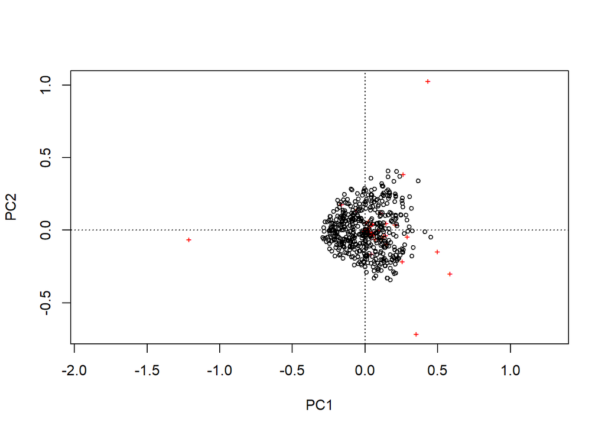

```r
fvc.hell<-decostand(fvc.otu, "hellinger")
fvc.pca<-rda(fvc.hell)
plot(fvc.pca)
```

```r
summary(fvc.pca)   # pc1 0.259  pc2 0.184
```

```
##
## Call:
## rda(X = fvc.hell)
##
## Partitioning of variance:
##               Inertia Proportion
## Total          0.2435          1
## Unconstrained  0.2435          1
##
## Eigenvalues, and their contribution to the variance
##
## Importance of components:
##                           PC1     PC2     PC3     PC4     PC5     PC6      PC7
## Eigenvalue            0.06312 0.04487 0.02257 0.01671 0.01314 0.01087 0.008498
## Proportion Explained  0.25925 0.18429 0.09269 0.06863 0.05396 0.04465 0.034904
## Cumulative Proportion 0.25925 0.44355 0.53624 0.60487 0.65883 0.70349 0.738389
##                            PC8      PC9    PC10     PC11     PC12     PC13
## Eigenvalue            0.007617 0.006289 0.00512 0.004247 0.003842 0.003281
## Proportion Explained  0.031287 0.025833 0.02103 0.017444 0.015782 0.013476
## Cumulative Proportion 0.769677 0.795510 0.81654 0.833985 0.849767 0.863243
##                           PC14     PC15     PC16     PC17     PC18     PC19
## Eigenvalue            0.003026 0.002537 0.002318 0.001952 0.001773 0.001666
## Proportion Explained  0.012430 0.010420 0.009521 0.008017 0.007281 0.006844
## Cumulative Proportion 0.875673 0.886093 0.895614 0.903631 0.910912 0.917756
##                           PC20     PC21     PC22     PC23     PC24      PC25
## Eigenvalue            0.001559 0.001416 0.001190 0.001160 0.000966 0.0008642
## Proportion Explained  0.006406 0.005817 0.004889 0.004765 0.003968 0.0035498
## Cumulative Proportion 0.924161 0.929978 0.934867 0.939632 0.943600 0.9471502
##                            PC26      PC27      PC28      PC29      PC30
## Eigenvalue            0.0008531 0.0007663 0.0007439 0.0006219 0.0006103
## Proportion Explained  0.0035039 0.0031476 0.0030557 0.0025545 0.0025067
## Cumulative Proportion 0.9506541 0.9538017 0.9568574 0.9594119 0.9619186
##                            PC31      PC32      PC33      PC34      PC35
## Eigenvalue            0.0005299 0.0004854 0.0004672 0.0004341 0.0004066
## Proportion Explained  0.0021767 0.0019936 0.0019188 0.0017830 0.0016701
## Cumulative Proportion 0.9640952 0.9660888 0.9680076 0.9697906 0.9714607
##                           PC36      PC37      PC38      PC39      PC40
## Eigenvalue            0.000377 0.0003371 0.0003312 0.0002872 0.0002756
## Proportion Explained  0.001549 0.0013845 0.0013606 0.0011797 0.0011320
## Cumulative Proportion 0.973009 0.9743939 0.9757545 0.9769342 0.9780662
```

[output cut: 1334 more lines]

```
## 13516.213A.0002.BAS  0.0040751
## 13516.213A.0003.BAS  0.1423382
## 13516.215A.0001.BAS -0.0982725
## 13516.215A.0002.BAS -0.0045255
## 13516.215A.0003.BAS -0.0583419
## 13516.223A.0001.BAS -0.0284003
## 13516.223A.0002.BAS  0.1699998
## 13516.223A.0003.BAS  0.0613048
## 13516.223A.0004.BAS -0.0493073
## 13516.231A.0003.BAS  0.0408593
## 13516.231A.0004.BAS -0.0265154
## 13516.231A.0005.BAS  0.0495896
## 13516.231A.0006.BAS  0.0750515
## 13516.232A.0001.BAS  0.0930501
## 13516.232A.0002.BAS  0.1272392
```

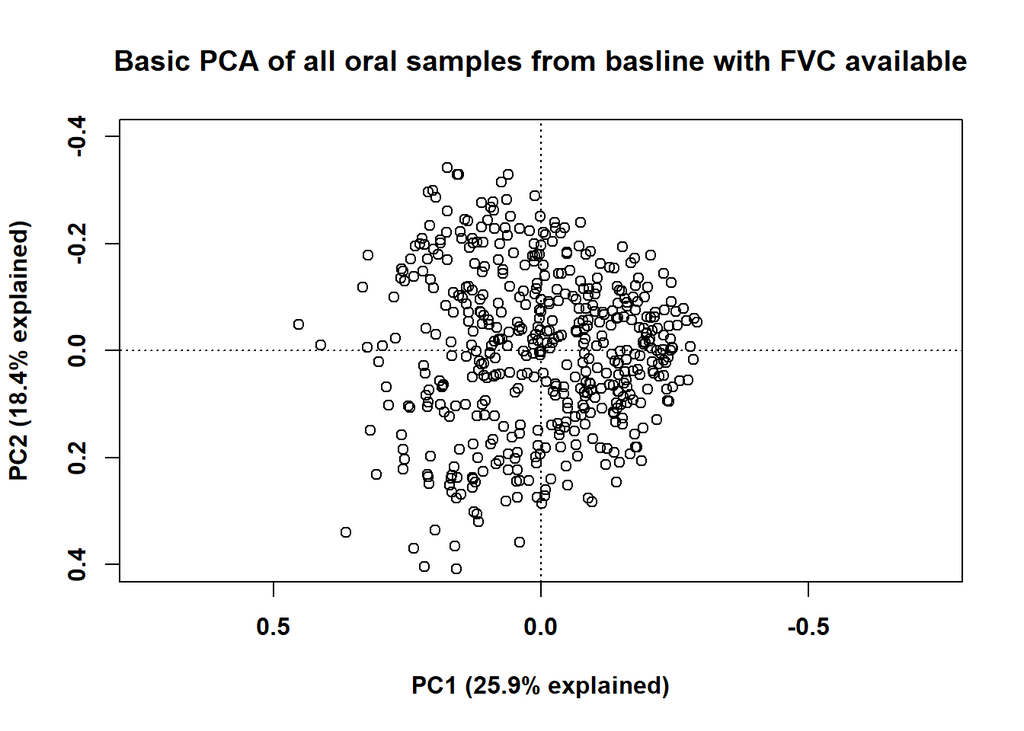

```r
par(mfrow=c(1,1))

plot(fvc.pca,type="n",font=2,font.lab=2,xlim=c(0.4, -0.4), ylim=c(0.4, -0.4), xlab="PC1 (25.9% explained)",
     ylab="PC2 (18.4% explained)",main="Basic PCA of all oral samples from basline with FVC available") # plotting the space
points(fvc.pca,pch=21,cex=1.0) #plotting the datapoints
```

##FVC B Diversity by FVC mean category lets try the mean ~ 70

```r
fvc.meta.otu$fvchigh<-ifelse(fvc.meta.otu$bfvcpp>=70, 1,0) #create variable for fvc over 70
table(fvc.meta.otu$fvchigh)
```

```
##
##   0   1
## 244 246
```

```r
fvchigh.70<-grep("1", fvc.meta.otu$fvchigh)
fvclow.70<-grep("0",  fvc.meta.otu$fvchigh)

samples.fvc<-as.character()
samples.fvc[fvchigh.70]<-"FVC>70"
samples.fvc[fvclow.70]<-"FVC<70"
samples.fvc<-as.factor(samples.fvc)
samples.fvc
```

```
##   [1] FVC>70 FVC<70 FVC>70 FVC<70 FVC>70 FVC>70 FVC>70 FVC>70 FVC>70 FVC>70
##  [11] FVC<70 FVC>70 FVC<70 FVC>70 FVC>70 FVC<70 FVC>70 FVC<70 FVC>70 FVC<70
##  [21] FVC>70 FVC<70 FVC<70 FVC<70 FVC<70 FVC<70 FVC>70 FVC>70 FVC<70 FVC<70
##  [31] FVC<70 FVC<70 FVC>70 FVC>70 FVC<70 FVC>70 FVC>70 FVC<70 FVC>70 FVC<70
##  [41] FVC>70 FVC>70 FVC>70 FVC<70 FVC>70 FVC<70 FVC<70 FVC<70 FVC>70 FVC<70
##  [51] FVC<70 FVC<70 FVC>70 FVC<70 FVC<70 FVC>70 FVC>70 FVC>70 FVC>70 FVC>70
##  [61] FVC<70 FVC>70 FVC<70 FVC>70 FVC<70 FVC<70 FVC<70 FVC>70 FVC>70 FVC<70
##  [71] FVC<70 FVC<70 FVC>70 FVC<70 FVC>70 FVC<70 FVC<70 FVC<70 FVC>70 FVC>70
##  [81] FVC>70 FVC<70 FVC>70 FVC<70 FVC<70 FVC>70 FVC>70 FVC>70 FVC>70 FVC>70
##  [91] FVC<70 FVC<70 FVC<70 FVC>70 FVC>70 FVC<70 FVC<70 FVC<70 FVC<70 FVC>70
## [101] FVC<70 FVC>70 FVC<70 FVC<70 FVC<70 FVC<70 FVC<70 FVC<70 FVC>70 FVC<70
## [111] FVC<70 FVC<70 FVC<70 FVC<70 FVC>70 FVC<70 FVC<70 FVC<70 FVC>70 FVC<70
## [121] FVC<70 FVC>70 FVC>70 FVC>70 FVC<70 FVC>70 FVC<70 FVC<70 FVC<70 FVC<70
## [131] FVC<70 FVC<70 FVC>70 FVC<70 FVC>70 FVC<70 FVC<70 FVC<70 FVC>70 FVC<70
## [141] FVC>70 FVC<70 FVC<70 FVC<70 FVC<70 FVC<70 FVC<70 FVC<70 FVC>70 FVC<70
```

[output cut: 35 more lines]

```r
set.seed(241279)
adonis(fvc.hell~samples.fvc, method="euclidean", permutations=10000)
```

```
##
## Call:
## adonis(formula = fvc.hell ~ samples.fvc, permutations = 10000,      method = "euclidean")
##
## Permutation: free
## Number of permutations: 10000
##
## Terms added sequentially (first to last)
##
##              Df SumsOfSqs MeanSqs F.Model      R2    Pr(>F)
## samples.fvc   1     1.087 1.08692  4.4964 0.00913 0.0005999 ***
## Residuals   488   117.965 0.24173         0.99087
## Total       489   119.052                 1.00000
## ---
## Signif. codes:  0 '***' 0.001 '**' 0.01 '*' 0.05 '.' 0.1 ' ' 1
```

```r
adonis(fvc.hell~fvc.meta.otu$bfvcpp, method="euclidean", permutations=10000)
```

```
##
## Call:
## adonis(formula = fvc.hell ~ fvc.meta.otu$bfvcpp, permutations = 10000,      method = "euclidean")
##
## Permutation: free
## Number of permutations: 10000
##
## Terms added sequentially (first to last)
##
##                      Df SumsOfSqs MeanSqs F.Model      R2 Pr(>F)
## fvc.meta.otu$bfvcpp   1     0.832 0.83229  3.4356 0.00699 0.0031 **
## Residuals           488   118.219 0.24225         0.99301
## Total               489   119.052                 1.00000
## ---
## Signif. codes:  0 '***' 0.001 '**' 0.01 '*' 0.05 '.' 0.1 ' ' 1
```

```r
adonis(fvc.hell~samples.fvc*fvc.meta.otu$sitenum, method="euclidean", permutations=10000)
```

```
##
## Call:
## adonis(formula = fvc.hell ~ samples.fvc * fvc.meta.otu$sitenum,      permutations = 10000, method = "euclidean")
##
## Permutation: free
## Number of permutations: 10000
##
## Terms added sequentially (first to last)
##
##                                   Df SumsOfSqs MeanSqs F.Model      R2
## samples.fvc                        1     1.087 1.08692  4.4977 0.00913
## fvc.meta.otu$sitenum               1     0.386 0.38584  1.5966 0.00324
## samples.fvc:fvc.meta.otu$sitenum   1     0.131 0.13092  0.5417 0.00110
## Residuals                        486   117.448 0.24166         0.98653
## Total                            489   119.052                 1.00000
##                                     Pr(>F)
## samples.fvc                      9.999e-05 ***
## fvc.meta.otu$sitenum                0.1056
## samples.fvc:fvc.meta.otu$sitenum    0.8658
## Residuals
## Total
## ---
## Signif. codes:  0 '***' 0.001 '**' 0.01 '*' 0.05 '.' 0.1 ' ' 1
```

```r
adonis(fvc.hell~samples.fvc*fvc.meta.otu$siteid, method="euclidean", permutations=10000)
```

```
##
## Call:
## adonis(formula = fvc.hell ~ samples.fvc * fvc.meta.otu$siteid,      permutations = 10000, method = "euclidean")
##
## Permutation: free
## Number of permutations: 10000
##
## Terms added sequentially (first to last)
##
##                                  Df SumsOfSqs MeanSqs F.Model      R2 Pr(>F)
## samples.fvc                       1     1.087 1.08692  4.5379 0.00913 0.0003
## fvc.meta.otu$siteid              32     9.365 0.29264  1.2218 0.07866 0.0149
## samples.fvc:fvc.meta.otu$siteid  27     5.845 0.21648  0.9038 0.04910 0.8259
## Residuals                       429   102.755 0.23952         0.86311
## Total                           489   119.052                 1.00000
##
## samples.fvc                     ***
## fvc.meta.otu$siteid             *
## samples.fvc:fvc.meta.otu$siteid
## Residuals
## Total
## ---
## Signif. codes:  0 '***' 0.001 '**' 0.01 '*' 0.05 '.' 0.1 ' ' 1
```

```r
biplot(fvc.pca, display="species")
```

[output not shown]

[output cut: 70 more lines]

[output not shown]

```r
text(fvc.pca, display="species")
```

[output not shown]

[output cut: 70 more lines]

[output not shown]

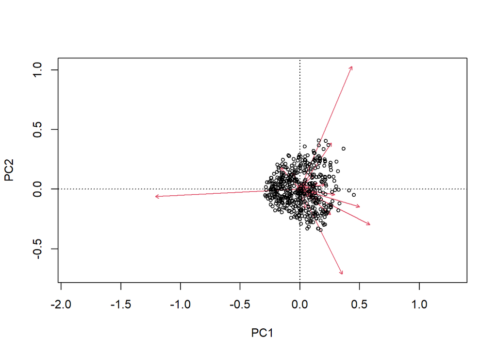

```r
biplot(fvc.pca)
```

Ok, so FVC looks highly significantly different based on stratifying high versus low

##FVC B diversity by tertiles

```r
fvc.meta.otu<-within(fvc.meta.otu, tertile<-as.integer(cut(bfvcpp, quantile(bfvcpp, probs=0:3/3), include.lowest=TRUE, labels=FALSE))) #generate a separate column with quartile ranges in category
```

```r
table(fvc.meta.otu$tertile) #pull table and count
```

```
##
##   1   2   3
## 164 163 163
```

```r
test.3<-data.frame(fvc.meta.otu$bfvcpp, fvc.meta.otu$tertile) #test by alignment
test.3   # tertile 3 is high, tertile 1 is low
```

```
##     fvc.meta.otu.bfvcpp fvc.meta.otu.tertile
## 1              90.18379                    3
## 2              32.02782                    1
## 3              83.00944                    3
## 4              56.72146                    1
## 5              74.27152                    2
## 6              85.06093                    3
## 7              94.60311                    3
## 8              93.46097                    3
## 9              82.50910                    3
## 10             74.63694                    2
## 11             64.47795                    2
## 12             84.43512                    3
## 13             68.66704                    2
## 14             72.69691                    2
```

[output cut: 476 more lines]

```r
summary(fvc.meta.otu$bfvcpp)
```

```
##    Min. 1st Qu.  Median    Mean 3rd Qu.    Max.
##   22.30   57.03   70.02   70.73   83.03  125.40
```

```r
fvc.tert.sum<-subset(fvc.meta.otu, select=c("bfvcpp", "tertile"))
colnames(fvc.tert.sum)
```

```
## [1] "bfvcpp"  "tertile"
```

```r
#write.csv(fvc.tert.sum, "cleanup_fvc_by_tertile.csv")
```

```r
tert1<-grep("3", fvc.meta.otu$tertile)
tert2<-grep("2", fvc.meta.otu$tertile)
tert3<-grep("1", fvc.meta.otu$tertile)

samples.tert.fvc<-as.character()
samples.tert.fvc[tert1]<-"high"
samples.tert.fvc[tert2]<-"intermediate"
samples.tert.fvc[tert3]<-"low"
samples.tert.fvc<-as.factor(samples.tert.fvc)
samples.tert.fvc
```

```
##   [1] high         low          high         low          intermediate
##   [6] high         high         high         high         intermediate
##  [11] intermediate high         intermediate intermediate high
##  [16] low          high         intermediate high         low
##  [21] intermediate low          low          intermediate low
##  [26] low          high         intermediate low          low
##  [31] low          intermediate intermediate high         low
##  [36] intermediate high         low          high         low
##  [41] high         high         intermediate low          high
##  [46] intermediate low          low          high         intermediate
##  [51] intermediate low          high         low          low
##  [56] intermediate intermediate intermediate intermediate intermediate
##  [61] low          high         low          high         intermediate
##  [66] intermediate intermediate intermediate intermediate intermediate
##  [71] low          low          high         low          high
```

[output cut: 84 more lines]

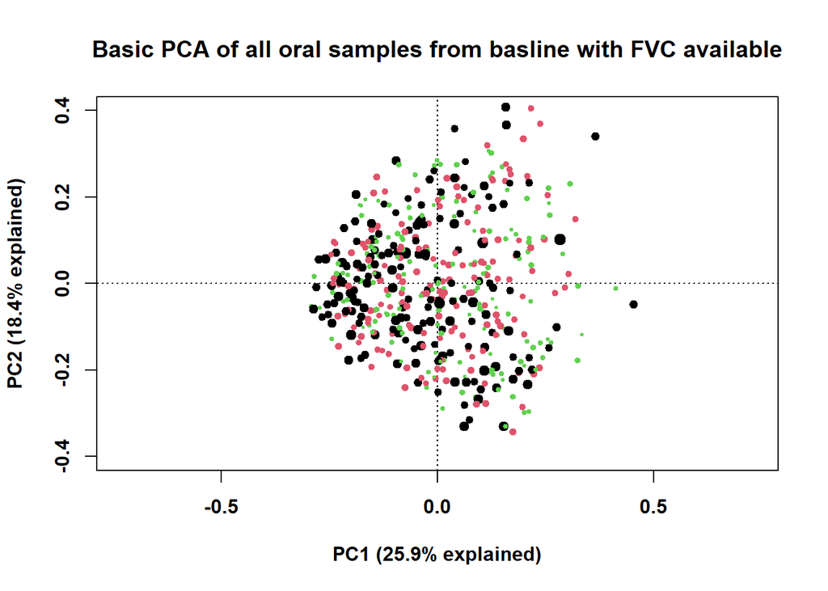

```r
par(mfrow=c(1,1))

plot(fvc.pca,type="n",font=2,font.lab=2, xlim=c(-0.4,0.4), ylim=c(-0.4,0.4),xlab="PC1 (25.9% explained)",
     ylab="PC2 (18.4% explained)",main="Basic PCA of all oral samples from basline with FVC available") # plotting the space
points(fvc.pca,pch=19,col=as.numeric(samples.tert.fvc), cex=fvc.meta.otu$bfvcpp*0.010)#plotting the datapoints
ordispider(fvc.pca, samples.tert.fvc,label=F,lty=0) #generating the spiders and centroids
```

```r
set.seed(241279)
adonis(fvc.hell~samples.tert.fvc, method="euclidean", permutations=10000)
```

```
##
## Call:
## adonis(formula = fvc.hell ~ samples.tert.fvc, permutations = 10000,      method = "euclidean")
##
## Permutation: free
## Number of permutations: 10000
##
## Terms added sequentially (first to last)
##
##                   Df SumsOfSqs MeanSqs F.Model      R2    Pr(>F)
## samples.tert.fvc   2      1.32 0.65976  2.7291 0.01108 0.0008999 ***
## Residuals        487    117.73 0.24175         0.98892
## Total            489    119.05                 1.00000
## ---
## Signif. codes:  0 '***' 0.001 '**' 0.01 '*' 0.05 '.' 0.1 ' ' 1
```

```r
adonis(fvc.hell[c(tert1,tert2),]~samples.tert.fvc[c(tert1,tert2)], method="euclidean", permutations=10000)
```

```
##
## Call:
## adonis(formula = fvc.hell[c(tert1, tert2), ] ~ samples.tert.fvc[c(tert1,      tert2)], permutations = 10000, method = "euclidean")
##
## Permutation: free
## Number of permutations: 10000
##
## Terms added sequentially (first to last)
##
##                                    Df SumsOfSqs MeanSqs F.Model      R2
## samples.tert.fvc[c(tert1, tert2)]   1     0.682 0.68218  2.8397 0.00869
## Residuals                         324    77.834 0.24023         0.99131
## Total                             325    78.516                 1.00000
##                                     Pr(>F)
## samples.tert.fvc[c(tert1, tert2)] 0.007499 **
## Residuals
## Total
## ---
## Signif. codes:  0 '***' 0.001 '**' 0.01 '*' 0.05 '.' 0.1 ' ' 1
```

```r
adonis(fvc.hell[c(tert1,tert3),]~samples.tert.fvc[c(tert1,tert3)], method="euclidean", permutations=10000)
```

```
##
## Call:
## adonis(formula = fvc.hell[c(tert1, tert3), ] ~ samples.tert.fvc[c(tert1,      tert3)], permutations = 10000, method = "euclidean")
##
## Permutation: free
## Number of permutations: 10000
##
## Terms added sequentially (first to last)
##
##                                    Df SumsOfSqs MeanSqs F.Model      R2 Pr(>F)
## samples.tert.fvc[c(tert1, tert3)]   1     1.062 1.06225  4.2966 0.01305  4e-04
## Residuals                         325    80.350 0.24723         0.98695
## Total                             326    81.412                 1.00000
##
## samples.tert.fvc[c(tert1, tert3)] ***
## Residuals
## Total
## ---
## Signif. codes:  0 '***' 0.001 '**' 0.01 '*' 0.05 '.' 0.1 ' ' 1
```

```r
adonis(fvc.hell~samples.tert.fvc*fvc.meta.otu$smokstat*fvc.meta.otu$siteid)
```

```
##
## Call:
## adonis(formula = fvc.hell ~ samples.tert.fvc * fvc.meta.otu$smokstat *      fvc.meta.otu$siteid)
##
## Permutation: free
## Number of permutations: 999
##
## Terms added sequentially (first to last)
##
##                                                             Df SumsOfSqs
## samples.tert.fvc                                             2     0.691
## fvc.meta.otu$smokstat                                        1     0.172
## fvc.meta.otu$siteid                                         32     4.271
## samples.tert.fvc:fvc.meta.otu$smokstat                       2     0.166
## samples.tert.fvc:fvc.meta.otu$siteid                        56     5.275
## fvc.meta.otu$smokstat:fvc.meta.otu$siteid                   27     2.539
## samples.tert.fvc:fvc.meta.otu$smokstat:fvc.meta.otu$siteid  39     3.922
## Residuals                                                  330    32.211
## Total                                                      489    49.248
##                                                            MeanSqs F.Model
## samples.tert.fvc                                           0.34569  3.5416
## fvc.meta.otu$smokstat                                      0.17196  1.7617
## fvc.meta.otu$siteid                                        0.13348  1.3675
## samples.tert.fvc:fvc.meta.otu$smokstat                     0.08314  0.8517
## samples.tert.fvc:fvc.meta.otu$siteid                       0.09420  0.9651
## fvc.meta.otu$smokstat:fvc.meta.otu$siteid                  0.09405  0.9636
## samples.tert.fvc:fvc.meta.otu$smokstat:fvc.meta.otu$siteid 0.10056  1.0302
## Residuals                                                  0.09761
## Total
##                                                                 R2 Pr(>F)
## samples.tert.fvc                                           0.01404  0.001 ***
## fvc.meta.otu$smokstat                                      0.00349  0.083 .
## fvc.meta.otu$siteid                                        0.08673  0.001 ***
## samples.tert.fvc:fvc.meta.otu$smokstat                     0.00338  0.636
## samples.tert.fvc:fvc.meta.otu$siteid                       0.10711  0.673
## fvc.meta.otu$smokstat:fvc.meta.otu$siteid                  0.05156  0.623
## samples.tert.fvc:fvc.meta.otu$smokstat:fvc.meta.otu$siteid 0.07963  0.372
## Residuals                                                  0.65405
## Total                                                      1.00000
## ---
## Signif. codes:  0 '***' 0.001 '**' 0.01 '*' 0.05 '.' 0.1 ' ' 1
```

```r
adonis(fvc.hell~samples.tert.fvc*fvc.meta.otu$age*fvc.meta.otu$SEX*fvc.meta.otu$smokstat*fvc.meta.otu$siteid)
```

```
##
## Call:
## adonis(formula = fvc.hell ~ samples.tert.fvc * fvc.meta.otu$age *      fvc.meta.otu$SEX * fvc.meta.otu$smokstat * fvc.meta.otu$siteid)
##
## Permutation: free
## Number of permutations: 999
##
## Terms added sequentially (first to last)
##
##                                                                              Df
## samples.tert.fvc                                                              2
## fvc.meta.otu$age                                                              1
## fvc.meta.otu$SEX                                                              1
## fvc.meta.otu$smokstat                                                         1
## fvc.meta.otu$siteid                                                          32
## samples.tert.fvc:fvc.meta.otu$age                                             2
## samples.tert.fvc:fvc.meta.otu$SEX                                             2
## fvc.meta.otu$age:fvc.meta.otu$SEX                                             1
## samples.tert.fvc:fvc.meta.otu$smokstat                                        2
## fvc.meta.otu$age:fvc.meta.otu$smokstat                                        1
## fvc.meta.otu$SEX:fvc.meta.otu$smokstat                                        1
## samples.tert.fvc:fvc.meta.otu$siteid                                         56
## fvc.meta.otu$age:fvc.meta.otu$siteid                                         30
## fvc.meta.otu$SEX:fvc.meta.otu$siteid                                         26
## fvc.meta.otu$smokstat:fvc.meta.otu$siteid                                    24
## samples.tert.fvc:fvc.meta.otu$age:fvc.meta.otu$SEX                            2
## samples.tert.fvc:fvc.meta.otu$age:fvc.meta.otu$smokstat                       2
## samples.tert.fvc:fvc.meta.otu$SEX:fvc.meta.otu$smokstat                       2
## fvc.meta.otu$age:fvc.meta.otu$SEX:fvc.meta.otu$smokstat                       1
## samples.tert.fvc:fvc.meta.otu$age:fvc.meta.otu$siteid                        44
## samples.tert.fvc:fvc.meta.otu$SEX:fvc.meta.otu$siteid                        24
## fvc.meta.otu$age:fvc.meta.otu$SEX:fvc.meta.otu$siteid                        16
## samples.tert.fvc:fvc.meta.otu$smokstat:fvc.meta.otu$siteid                   28
## fvc.meta.otu$age:fvc.meta.otu$smokstat:fvc.meta.otu$siteid                   17
## fvc.meta.otu$SEX:fvc.meta.otu$smokstat:fvc.meta.otu$siteid                    6
## samples.tert.fvc:fvc.meta.otu$age:fvc.meta.otu$SEX:fvc.meta.otu$smokstat      2
## samples.tert.fvc:fvc.meta.otu$age:fvc.meta.otu$SEX:fvc.meta.otu$siteid        4
## samples.tert.fvc:fvc.meta.otu$age:fvc.meta.otu$smokstat:fvc.meta.otu$siteid   8
## Residuals                                                                   151
## Total                                                                       489
```

[output cut: 173 more lines]

```
## samples.tert.fvc:fvc.meta.otu$SEX:fvc.meta.otu$smokstat
## fvc.meta.otu$age:fvc.meta.otu$SEX:fvc.meta.otu$smokstat
## samples.tert.fvc:fvc.meta.otu$age:fvc.meta.otu$siteid
## samples.tert.fvc:fvc.meta.otu$SEX:fvc.meta.otu$siteid
## fvc.meta.otu$age:fvc.meta.otu$SEX:fvc.meta.otu$siteid
## samples.tert.fvc:fvc.meta.otu$smokstat:fvc.meta.otu$siteid
## fvc.meta.otu$age:fvc.meta.otu$smokstat:fvc.meta.otu$siteid
## fvc.meta.otu$SEX:fvc.meta.otu$smokstat:fvc.meta.otu$siteid
## samples.tert.fvc:fvc.meta.otu$age:fvc.meta.otu$SEX:fvc.meta.otu$smokstat
## samples.tert.fvc:fvc.meta.otu$age:fvc.meta.otu$SEX:fvc.meta.otu$siteid
## samples.tert.fvc:fvc.meta.otu$age:fvc.meta.otu$smokstat:fvc.meta.otu$siteid
## Residuals
## Total
## ---
## Signif. codes:  0 '***' 0.001 '**' 0.01 '*' 0.05 '.' 0.1 ' ' 1
```

[output not shown]

[output cut: 70 more lines]

[output not shown]

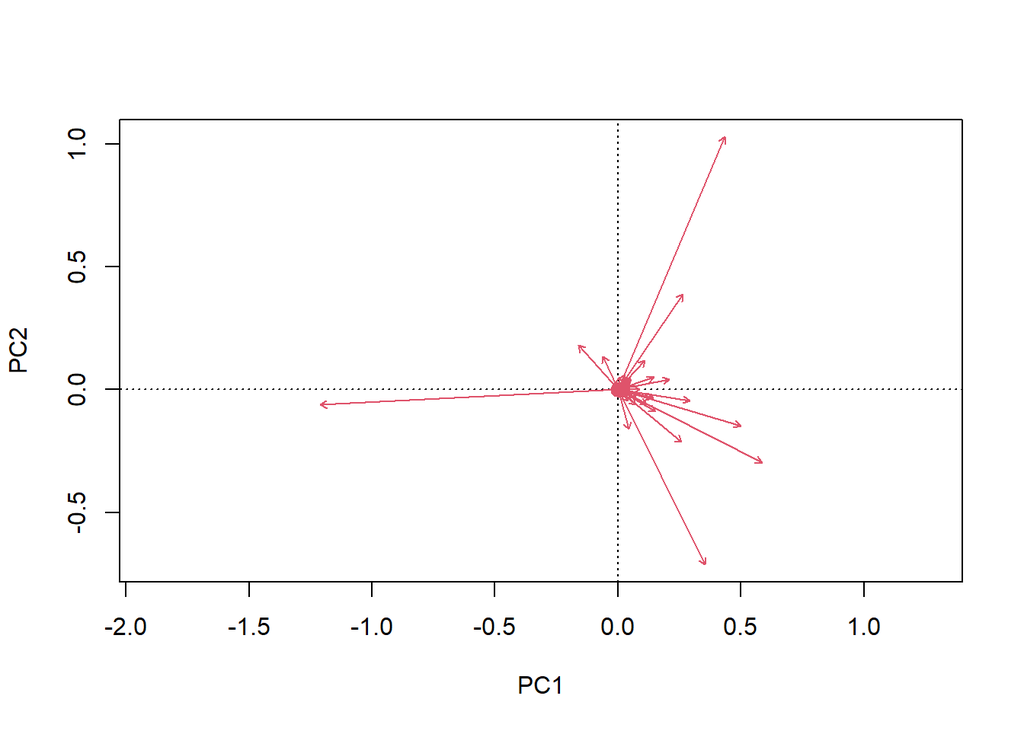

```r
biplot(fvc.pca, display="species")
```

```r
biplot(fvc.pca, display="species")
```

[output not shown]

[output cut: 70 more lines]

[output not shown]

```r
text(fvc.pca, display="species")
```

Ok. Whats the association with it as a continuous variable

```r
adonis(fvc.hell~fvc.meta.otu$bfvcpp, method="euclidean", permuatations=10000)
```

```
##
## Call:
## adonis(formula = fvc.hell ~ fvc.meta.otu$bfvcpp, method = "euclidean",      permuatations = 10000)
##
## Permutation: free
## Number of permutations: 999
##
## Terms added sequentially (first to last)
##
##                      Df SumsOfSqs MeanSqs F.Model      R2 Pr(>F)
## fvc.meta.otu$bfvcpp   1     0.832 0.83229  3.4356 0.00699  0.004 **
## Residuals           488   118.219 0.24225         0.99301
## Total               489   119.052                 1.00000
## ---
## Signif. codes:  0 '***' 0.001 '**' 0.01 '*' 0.05 '.' 0.1 ' ' 1
```

```r
adonis(fvc.hell~fvc.meta.otu$bfvcpp*fvc.meta.otu$age*fvc.meta.otu$SEX*fvc.meta.otu$siteid*fvc.meta.otu$smokstat, method="euclidean", permuatations=10000)
```

```
##
## Call:
## adonis(formula = fvc.hell ~ fvc.meta.otu$bfvcpp * fvc.meta.otu$age *      fvc.meta.otu$SEX * fvc.meta.otu$siteid * fvc.meta.otu$smokstat,      method = "euclidean", permuatations = 10000)
##
## Permutation: free
## Number of permutations: 999
##
## Terms added sequentially (first to last)
##
##                                                                                 Df
## fvc.meta.otu$bfvcpp                                                              1
## fvc.meta.otu$age                                                                 1
## fvc.meta.otu$SEX                                                                 1
## fvc.meta.otu$siteid                                                             32
## fvc.meta.otu$smokstat                                                            1
## fvc.meta.otu$bfvcpp:fvc.meta.otu$age                                             1
## fvc.meta.otu$bfvcpp:fvc.meta.otu$SEX                                             1
## fvc.meta.otu$age:fvc.meta.otu$SEX                                                1
## fvc.meta.otu$bfvcpp:fvc.meta.otu$siteid                                         32
## fvc.meta.otu$age:fvc.meta.otu$siteid                                            30
## fvc.meta.otu$SEX:fvc.meta.otu$siteid                                            26
## fvc.meta.otu$bfvcpp:fvc.meta.otu$smokstat                                        1
## fvc.meta.otu$age:fvc.meta.otu$smokstat                                           1
## fvc.meta.otu$SEX:fvc.meta.otu$smokstat                                           1
## fvc.meta.otu$siteid:fvc.meta.otu$smokstat                                       25
## fvc.meta.otu$bfvcpp:fvc.meta.otu$age:fvc.meta.otu$SEX                            1
## fvc.meta.otu$bfvcpp:fvc.meta.otu$age:fvc.meta.otu$siteid                        24
## fvc.meta.otu$bfvcpp:fvc.meta.otu$SEX:fvc.meta.otu$siteid                        20
## fvc.meta.otu$age:fvc.meta.otu$SEX:fvc.meta.otu$siteid                           15
## fvc.meta.otu$bfvcpp:fvc.meta.otu$age:fvc.meta.otu$smokstat                       1
## fvc.meta.otu$bfvcpp:fvc.meta.otu$SEX:fvc.meta.otu$smokstat                       1
## fvc.meta.otu$age:fvc.meta.otu$SEX:fvc.meta.otu$smokstat                          1
## fvc.meta.otu$bfvcpp:fvc.meta.otu$siteid:fvc.meta.otu$smokstat                   23
## fvc.meta.otu$age:fvc.meta.otu$siteid:fvc.meta.otu$smokstat                      22
## fvc.meta.otu$SEX:fvc.meta.otu$siteid:fvc.meta.otu$smokstat                      10
## fvc.meta.otu$bfvcpp:fvc.meta.otu$age:fvc.meta.otu$SEX:fvc.meta.otu$siteid        6
## fvc.meta.otu$bfvcpp:fvc.meta.otu$age:fvc.meta.otu$SEX:fvc.meta.otu$smokstat      1
## fvc.meta.otu$bfvcpp:fvc.meta.otu$age:fvc.meta.otu$siteid:fvc.meta.otu$smokstat  15
## fvc.meta.otu$bfvcpp:fvc.meta.otu$SEX:fvc.meta.otu$siteid:fvc.meta.otu$smokstat   4
## fvc.meta.otu$age:fvc.meta.otu$SEX:fvc.meta.otu$siteid:fvc.meta.otu$smokstat      2
```

[output cut: 187 more lines]

```
## fvc.meta.otu$bfvcpp:fvc.meta.otu$age:fvc.meta.otu$smokstat
## fvc.meta.otu$bfvcpp:fvc.meta.otu$SEX:fvc.meta.otu$smokstat
## fvc.meta.otu$age:fvc.meta.otu$SEX:fvc.meta.otu$smokstat
## fvc.meta.otu$bfvcpp:fvc.meta.otu$siteid:fvc.meta.otu$smokstat
## fvc.meta.otu$age:fvc.meta.otu$siteid:fvc.meta.otu$smokstat
## fvc.meta.otu$SEX:fvc.meta.otu$siteid:fvc.meta.otu$smokstat
## fvc.meta.otu$bfvcpp:fvc.meta.otu$age:fvc.meta.otu$SEX:fvc.meta.otu$siteid
## fvc.meta.otu$bfvcpp:fvc.meta.otu$age:fvc.meta.otu$SEX:fvc.meta.otu$smokstat
## fvc.meta.otu$bfvcpp:fvc.meta.otu$age:fvc.meta.otu$siteid:fvc.meta.otu$smokstat
## fvc.meta.otu$bfvcpp:fvc.meta.otu$SEX:fvc.meta.otu$siteid:fvc.meta.otu$smokstat
## fvc.meta.otu$age:fvc.meta.otu$SEX:fvc.meta.otu$siteid:fvc.meta.otu$smokstat
## Residuals
## Total
## ---
## Signif. codes:  0 '***' 0.001 '**' 0.01 '*' 0.05 '.' 0.1 ' ' 1
```

```r
adonis(fvc.otu~fvc.meta.otu$bfvcpp, permutations=10000)
```

```
##
## Call:
## adonis(formula = fvc.otu ~ fvc.meta.otu$bfvcpp, permutations = 10000)
##
## Permutation: free
## Number of permutations: 10000
##
## Terms added sequentially (first to last)
##
##                      Df SumsOfSqs MeanSqs F.Model      R2  Pr(>F)
## fvc.meta.otu$bfvcpp   1     0.461 0.46063  1.8506 0.00378 0.07999 .
## Residuals           488   121.471 0.24892         0.99622
## Total               489   121.931                 1.00000
## ---
## Signif. codes:  0 '***' 0.001 '**' 0.01 '*' 0.05 '.' 0.1 ' ' 1
```

##FVC by Community collaspe Is this associated with community collaspe (higher single taxa abundance)

```r
fvc.otu.norm<-decostand(fvc.otu, "total")*100
fvc.Max_OTU<- apply(fvc.otu.norm[,], 1, max) #NEES TO BE NORMALIZED
fvc.Max_OTU
```

```
## 13516.113A.0001.BAS 13516.113A.0002.BAS 13516.113A.0003.BAS 13516.113A.0004.BAS
##            80.12007            42.19634            91.55990            62.18512
## 13516.113A.0005.BAS 13516.113A.0006.BAS 13516.113A.0007.BAS 13516.113A.0008.BAS
##            57.65096            87.49005            65.04203            91.38204
## 13516.113A.0009.BAS 13516.113A.0010.BAS 13516.113A.0011.BAS 13516.113A.0012.BAS
##            81.21168            87.72630            89.10046            50.95389
## 13516.113A.0013.BAS 13516.113A.0014.BAS 13516.113A.0015.BAS 13516.113A.0016.BAS
##            30.43066            67.36297            68.15634            49.83035
## 13516.113A.0017.BAS 13516.113A.0018.BAS 13516.113A.0019.BAS 13516.113A.0020.BAS
##            62.39599            47.51421            58.24385            76.23837
## 13516.113A.0021.BAS 13516.113A.0022.BAS 13516.113A.0023.BAS 13516.113A.0024.BAS
##            69.10274            77.17427            30.93492            29.59574
## 13516.113A.0025.BAS 13516.113A.0026.BAS 13516.113A.0027.BAS 13516.113A.0028.BAS
##            87.74741            98.04907            79.81840            72.15412
## 13516.113A.0029.BAS 13516.113A.0030.BAS 13516.113A.0031.BAS 13516.113A.0032.BAS
##            19.01945            76.23913            38.67380            30.17504
## 13516.113A.0033.BAS 13516.113A.0034.BAS 13516.113A.0035.BAS 13516.113A.0036.BAS
##            58.13231            68.04998            57.91354            59.63404
## 13516.113A.0037.BAS 13516.113A.0038.BAS 13516.121A.0001.BAS 13516.121A.0002.BAS
##            63.44802            37.24063            85.23319            91.96783
## 13516.121A.0003.BAS 13516.121A.0004.BAS 13516.121A.0005.BAS 13516.121A.0006.BAS
##            50.30079            54.47247            45.82506            76.87417
## 13516.121A.0007.BAS 13516.121A.0008.BAS 13516.121A.0009.BAS 13516.121A.0010.BAS
##            47.60329            83.52573            58.62248            71.90621
## 13516.121A.0011.BAS 13516.121A.0012.BAS 13516.121A.0013.BAS 13516.121A.0014.BAS
##            65.55393            76.26505            82.96790            38.55278
## 13516.121A.0015.BAS 13516.121A.0016.BAS 13516.121A.0017.BAS 13516.121A.0018.BAS
##            38.82593            57.75503            62.71836            44.15422
## 13516.136A.0001.BAS 13516.136A.0002.BAS 13516.136A.0003.BAS 13516.136A.0004.BAS
##            34.98597            48.99381            42.47847            51.74177
## 13516.136A.0005.BAS 13516.136A.0006.BAS 13516.136A.0007.BAS 13516.136A.0008.BAS
##            45.39479            26.95948            25.74430            37.05344
## 13516.136A.0009.BAS 13516.155A.0001.BAS 13516.155A.0002.BAS 13516.155A.0003.BAS
##            28.23123            48.88272            69.49686            67.90886
## 13516.155A.0004.BAS 13516.155A.0005.BAS 13516.155A.0006.BAS 13516.155A.0007.BAS
##            27.83686            87.92228            29.26799            38.85925
## 13516.155A.0008.BAS 13516.155A.0009.BAS 13516.155A.0010.BAS 13516.155A.0011.BAS
##            58.94888            95.52904            42.17713            82.20931
## 13516.155A.0012.BAS 13516.155A.0013.BAS 13516.155A.0014.BAS 13516.155A.0015.BAS
##            31.54474            66.31563            35.00834            71.59984
```

[output cut: 191 more lines]

```
##            24.36011            46.69067            59.48373            36.46230
## 13516.210A.0014.BAS 13516.210A.0015.BAS 13516.210A.0016.BAS 13516.210A.0017.BAS
##            44.36276            23.85305            52.82208            33.53236
## 13516.210A.0018.BAS 13516.210A.0019.BAS 13516.210A.0020.BAS 13516.211A.0001.BAS
##            22.54210            20.49685            35.61825            60.14559
## 13516.211A.0002.BAS 13516.211A.0003.BAS 13516.213A.0001.BAS 13516.213A.0002.BAS
##            41.93396            70.41351            88.88129            54.58110
## 13516.213A.0003.BAS 13516.215A.0001.BAS 13516.215A.0002.BAS 13516.215A.0003.BAS
##            44.54564            91.05766            55.43462            45.08605
## 13516.223A.0001.BAS 13516.223A.0002.BAS 13516.223A.0003.BAS 13516.223A.0004.BAS
##            48.03810            31.82970            78.59225            46.66198
## 13516.231A.0003.BAS 13516.231A.0004.BAS 13516.231A.0005.BAS 13516.231A.0006.BAS
##            56.96584            40.26789            79.33565            25.09788
## 13516.232A.0001.BAS 13516.232A.0002.BAS
##            45.19954            31.01330
```

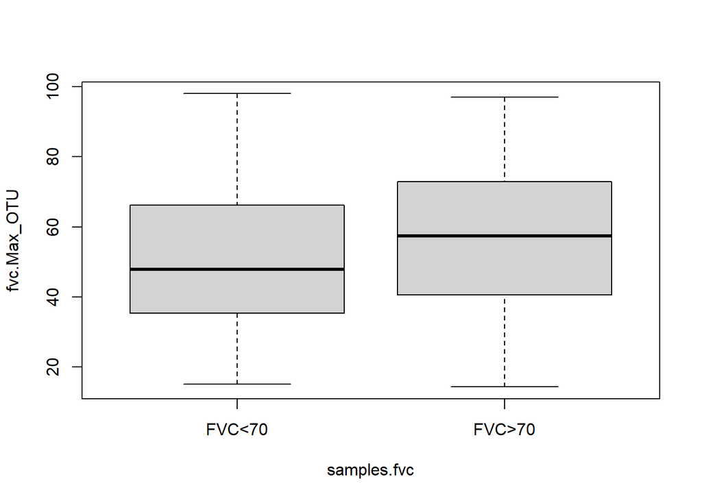

```r
boxplot(fvc.Max_OTU~samples.fvc)
```

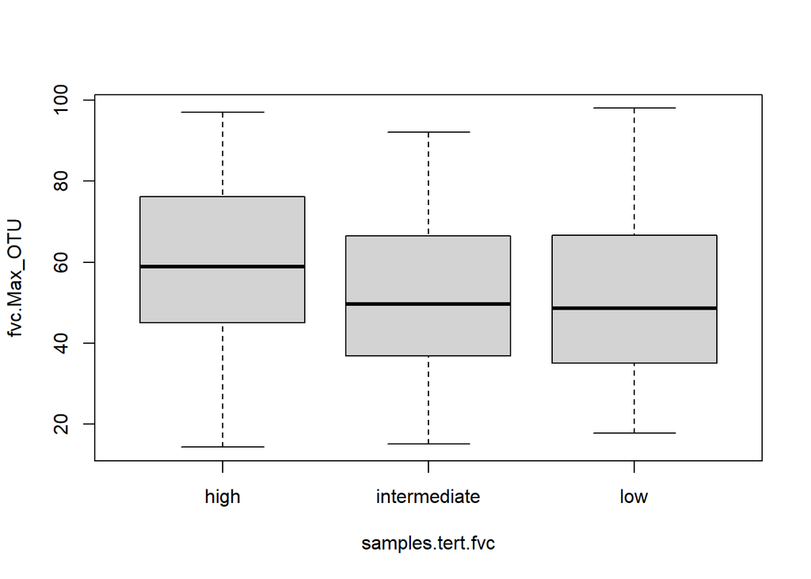

```r
boxplot(fvc.Max_OTU~samples.tert.fvc)
```

```r
summary(aov(fvc.Max_OTU~samples.tert.fvc))
```

```
##                   Df Sum Sq Mean Sq F value   Pr(>F)
## samples.tert.fvc   2   5736  2867.8   7.244 0.000794 ***
## Residuals        487 192800   395.9
## ---
## Signif. codes:  0 '***' 0.001 '**' 0.01 '*' 0.05 '.' 0.1 ' ' 1
```

```r
shapiro.test(fvc.Max_OTU) #NOT NORMAL
```

```
##
##  Shapiro-Wilk normality test
##
## data:  fvc.Max_OTU
## W = 0.97325, p-value = 8.345e-08
```

```r
kruskal.test(fvc.Max_OTU~samples.tert.fvc) #P=0.0006
```

```
##
##  Kruskal-Wallis rank sum test
##
## data:  fvc.Max_OTU by samples.tert.fvc
## Kruskal-Wallis chi-squared = 14.582, df = 2, p-value = 0.0006817
```

```r
fvc.meta.otu$tertile<-as.factor(fvc.meta.otu$tertile)
pairwise.wilcox.test(fvc.Max_OTU, samples.tert.fvc, p.adjust.method = "BH")
```

```
##
##  Pairwise comparisons using Wilcoxon rank sum test with continuity correction
##
## data:  fvc.Max_OTU and samples.tert.fvc
##
##              high   intermediate
## intermediate 0.0023 -
## low          0.0018 0.8100
##
## P value adjustment method: BH
```

```r
data.1<-cbind(fvc.Max_OTU, fvc.meta.otu$tertile)   #bind data by column
data.1<-as.data.frame(data.1)      #generate data frame
colnames(data.1)[2]="fvc_tertile"  #rename col 2 in data as fvc_tertile
colnames(data.1)
```

```
## [1] "fvc.Max_OTU" "fvc_tertile"
```

```r
data.1$fvc_tertile<-as.factor(data.1$fvc_tertile)
#write.csv(data.1, "CleanUp.bas.maxOTU.fvctertile.csv")
```

ok lets try minimal R tips to plot data=data.1 which is a data frame

```r
data.1 %>%
  group_by(fvc_tertile) %>%
  summarize(mean=mean(fvc.Max_OTU), sd=sd(fvc.Max_OTU))
```

```
## # A tibble: 3 x 3
##   fvc_tertile  mean    sd
##   <fct>       <dbl> <dbl>
## 1 1            51.6  19.9
## 2 2            52.1  19.5
## 3 3            59.1  20.3
```

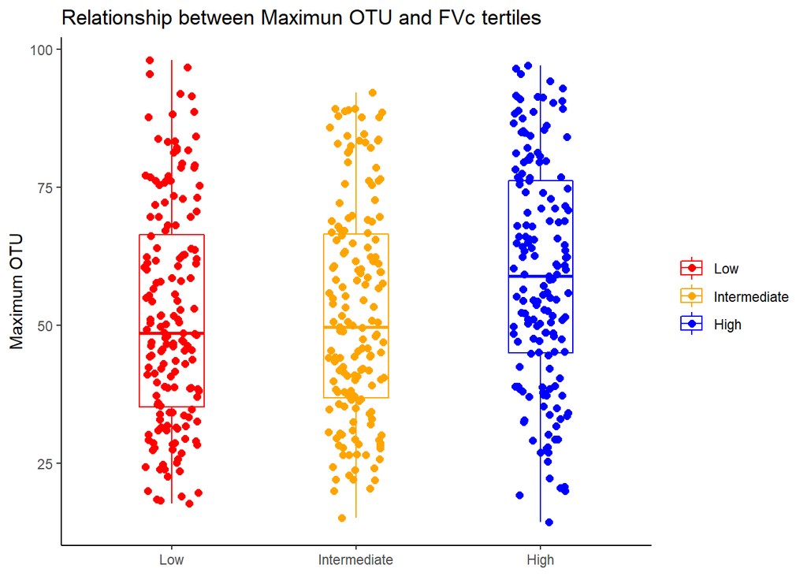

```r
ggplot(data.1, aes(x=fvc_tertile, y=fvc.Max_OTU, color=fvc_tertile))+
  geom_boxplot(width=0.35)+
  geom_jitter(shape=19, size=2, width=0.15)+
  scale_color_manual(name=NULL,
                     values=c("red", "orange", "blue"),
                     breaks=c("1", "2", "3"),
                     labels=c("Low", "Intermediate", "High"))+
  scale_x_discrete(limits=c("1", "2", "3"),
                   labels=c("Low", "Intermediate", "High"))+
  labs(title="Relationship between Maximun OTU and FVc tertiles",
       x=NULL,
       y="Maximum OTU")+
  theme_classic()
```

```r
aov.maxotu.tert<-aov(fvc.Max_OTU~samples.tert.fvc)
summary(aov.maxotu.tert)
```

```
##                   Df Sum Sq Mean Sq F value   Pr(>F)
## samples.tert.fvc   2   5736  2867.8   7.244 0.000794 ***
## Residuals        487 192800   395.9
## ---
## Signif. codes:  0 '***' 0.001 '**' 0.01 '*' 0.05 '.' 0.1 ' ' 1
```

```r
TukeyHSD(aov.maxotu.tert)
```

```
##   Tukey multiple comparisons of means
##     95% family-wise confidence level
##
## Fit: aov(formula = fvc.Max_OTU ~ samples.tert.fvc)
##
## $samples.tert.fvc
##                         diff        lwr       upr     p adj
## intermediate-high -6.9935875 -12.174953 -1.812222 0.0045620
## low-high          -7.5008807 -12.674342 -2.327419 0.0020405
## low-intermediate  -0.5072932  -5.680755  4.666168 0.9711322
```

#FVC and Alpha Diversity

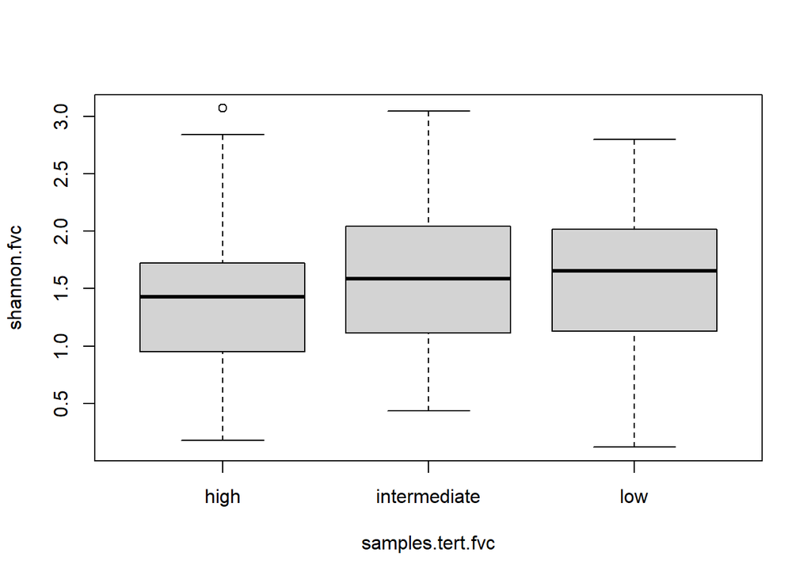

```r
shannon.fvc<-diversity(fvc.otu, "shannon")
boxplot(shannon.fvc~samples.tert.fvc)
```